# team

allan juarez

```r
library(tidyverse)
library(lubridate)
```

```r
library(ggplot2)
library(dplyr)
library(maps)
library(readxl)
```

[output not shown]

[output cut: 38 more lines]

[output not shown]

[output cut: 54 more lines]

## 1. number of accidents

```r
one <- table(acc1$DAY_WEEK)
one
```

```
##
##    1    2    3    4    5    6    7
## 5360 4374 4347 4314 4621 5358 5873
```

Looking at the table numbers 1,7, and 6 there is a spike in more accidents. This could be because people are out and about on the weekend since they dont have school or work that day or the next day.

##2. Data frame of people fatally injured

```r
two <- acc2 %>% filter(INJ_SEV == '4')
summary(two)
```

```
##      STATE          ST_CASE          VE_FORMS          VEH_NO
##  Min.   : 1.00   Min.   : 10001   Min.   : 1.000   Min.   : 0.000
##  1st Qu.:12.00   1st Qu.:122060   1st Qu.: 1.000   1st Qu.: 1.000
##  Median :26.00   Median :260876   Median : 1.000   Median : 1.000
##  Mean   :27.27   Mean   :273427   Mean   : 1.574   Mean   : 1.023
##  3rd Qu.:42.00   3rd Qu.:420575   3rd Qu.: 2.000   3rd Qu.: 1.000
##  Max.   :56.00   Max.   :560105   Max.   :32.000   Max.   :19.000
##
##      PER_NO          STR_VEH           COUNTY            DAY
##  Min.   : 1.000   Min.   :0.0000   Min.   :  1.00   Min.   : 1.00
##  1st Qu.: 1.000   1st Qu.:0.0000   1st Qu.: 31.00   1st Qu.: 8.00
##  Median : 1.000   Median :0.0000   Median : 71.00   Median :16.00
##  Mean   : 1.257   Mean   :0.1912   Mean   : 92.45   Mean   :15.68
##  3rd Qu.: 1.000   3rd Qu.:0.0000   3rd Qu.:117.00   3rd Qu.:23.00
##  Max.   :20.000   Max.   :4.0000   Max.   :820.00   Max.   :31.00
##
##      MONTH             HOUR           MINUTE         RUR_URB
##  Min.   : 1.000   Min.   : 0.00   Min.   : 0.00   Min.   :1.000
##  1st Qu.: 4.000   1st Qu.: 7.00   1st Qu.:14.00   1st Qu.:1.000
##  Median : 7.000   Median :14.00   Median :30.00   Median :2.000
##  Mean   : 6.668   Mean   :13.53   Mean   :28.99   Mean   :1.672
##  3rd Qu.:10.000   3rd Qu.:19.00   3rd Qu.:44.00   3rd Qu.:2.000
##  Max.   :12.000   Max.   :99.00   Max.   :99.00   Max.   :9.000
##
##     FUNC_SYS         HARM_EV         MAN_COLL         SCH_BUS
##  Min.   : 1.000   Min.   : 1.00   Min.   : 0.000   Min.   :0.000000
##  1st Qu.: 3.000   1st Qu.: 9.00   1st Qu.: 0.000   1st Qu.:0.000000
##  Median : 4.000   Median :12.00   Median : 0.000   Median :0.000000
##  Mean   : 6.111   Mean   :17.97   Mean   : 1.955   Mean   :0.002558
##  3rd Qu.: 5.000   3rd Qu.:30.00   3rd Qu.: 2.000   3rd Qu.:0.000000
##  Max.   :99.000   Max.   :99.00   Max.   :99.000   Max.   :1.000000
##
##       MAKE          MAK_MOD         BODY_TYP        MOD_YEAR       TOW_VEH
##  Min.   : 2.00   Min.   : 2001   Min.   : 1.00   Min.   :1927   Min.   :0.000
##  1st Qu.:18.00   1st Qu.:18002   1st Qu.: 4.00   1st Qu.:2001   1st Qu.:0.000
##  Median :35.00   Median :35043   Median :14.00   Median :2005   Median :0.000
##  Mean   :35.98   Mean   :36307   Mean   :26.98   Mean   :2076   Mean   :0.029
##  3rd Qu.:52.00   3rd Qu.:52034   3rd Qu.:34.00   3rd Qu.:2011   3rd Qu.:0.000
##  Max.   :99.00   Max.   :99999   Max.   :99.00   Max.   :9999   Max.   :9.000
##  NA's   :6947    NA's   :6947    NA's   :6947    NA's   :6947   NA's   :6947
```

[output cut: 73 more lines]

```
##  Min.   : 0.0000   Min.   : 0.0000   Min.   : 0.0000   Min.   :0.0000
##  1st Qu.: 0.0000   1st Qu.: 0.0000   1st Qu.: 0.0000   1st Qu.:0.0000
##  Median : 0.0000   Median : 0.0000   Median : 0.0000   Median :0.0000
##  Mean   : 0.5031   Mean   : 0.2602   Mean   : 0.2586   Mean   :0.6953
##  3rd Qu.: 0.0000   3rd Qu.: 0.0000   3rd Qu.: 0.0000   3rd Qu.:0.0000
##  Max.   :99.0000   Max.   :99.0000   Max.   :99.0000   Max.   :9.0000
##
##     HISPANIC          RACE          LOCATION
##  Min.   : 1.00   Min.   : 1.00   Min.   : 0.000
##  1st Qu.: 7.00   1st Qu.: 1.00   1st Qu.: 0.000
##  Median : 7.00   Median : 1.00   Median : 0.000
##  Mean   :16.28   Mean   :11.34   Mean   : 2.182
##  3rd Qu.: 7.00   3rd Qu.: 2.00   3rd Qu.: 0.000
##  Max.   :99.00   Max.   :99.00   Max.   :99.000
##
```

4 is the number to see who died so this dataframe only contains that

##3. Data

```r
three <- acc2 %>% group_by(MAKE, STATE) %>% drop_na(MAKE) %>% summarise(big_car = n())
three <- three %>% group_by(STATE) %>% filter(big_car == max(big_car)) %>% arrange(STATE)
head(three)
```

```
## # A tibble: 6 x 3
## # Groups:   STATE [6]
##    MAKE STATE big_car
##   <int> <int>   <int>
## 1    20     1     293
## 2    20     2      29
## 3    12     4     305
## 4    20     5     171
## 5    49     6    1079
## 6    12     8     176
```

##4. Map

```r
states <- read_excel('../ds202_lab5/easyName.xlsx')
states <- states %>% rename(Name = 'State Name', STATE = 'State Code')
states <- states %>% distinct( Name, STATE) %>% mutate(STATE = as.integer(STATE))
three <- three %>% inner_join(states)
```

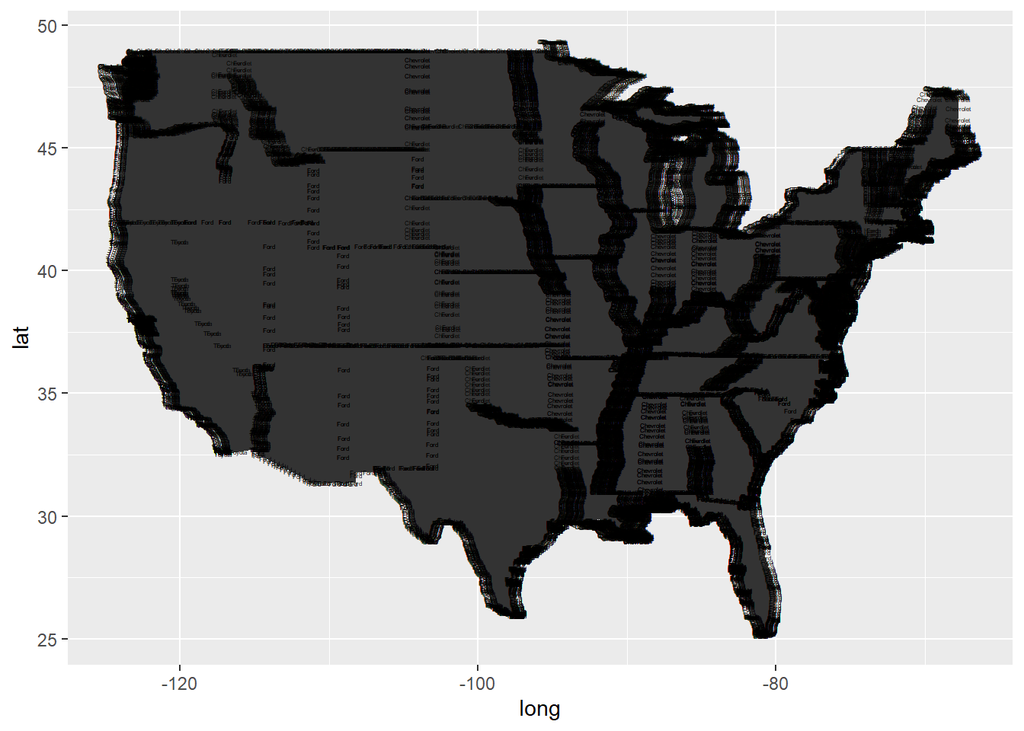

```r
make <-  read_excel('../ds202_lab5/makeCodes.xlsx')
three <- three %>% mutate(State = tolower(Name))


statesOut <- map_data('state')
three <- three %>% inner_join(statesOut , by = c('State' = 'region'))
 three <- three %>% inner_join(make , by = c('MAKE'='Codes'))

ggplot(statesOut, aes(x=long, y=lat)) + geom_polygon(aes(group = group)) + geom_text(data=three, aes(label = Make), size = 1)
```

THe map is a little messy I couldnt quite get the labels to just be the center of the states they turned out to be the borders of the state which is annoying.

##5. join data

```r
five <- acc1 %>% right_join(acc2)
str(five)
```

```
## 'data.frame':    84921 obs. of  107 variables:
##  $ STATE     : int  1 1 1 1 1 1 1 1 1 1 ...
##  $ ST_CASE   : int  10001 10002 10003 10003 10003 10004 10005 10005 10006 10006 ...
##  $ VE_TOTAL  : int  1 1 3 3 3 1 1 1 2 2 ...
##  $ VE_FORMS  : int  1 1 3 3 3 1 1 1 2 2 ...
##  $ PVH_INVL  : int  0 0 0 0 0 0 0 0 0 0 ...
##  $ PEDS      : int  0 0 0 0 0 0 0 0 0 0 ...
##  $ PERNOTMVIT: int  0 0 0 0 0 0 0 0 0 0 ...
##  $ PERMVIT   : int  1 1 3 3 3 1 2 2 4 4 ...
##  $ PERSONS   : int  1 1 3 3 3 1 2 2 4 4 ...
##  $ COUNTY    : int  73 89 101 101 101 73 13 13 49 49 ...
##  $ CITY      : int  330 1730 2130 2130 2130 350 0 0 0 0 ...
##  $ DAY       : int  19 14 31 31 31 1 1 1 6 6 ...
##  $ MONTH     : int  2 2 1 1 1 1 1 1 1 1 ...
##  $ YEAR      : int  2017 2017 2017 2017 2017 2017 2017 2017 2017 2017 ...
```

[output cut: 86 more lines]

##6.Tally number of accidents

```r
six <- five %>% drop_na(DAY_WEEK,HOUR) %>%filter(SEX != 9) %>% filter(SEX != 8)%>% select(DAY_WEEK, HOUR, SEX) %>% group_by(DAY_WEEK, HOUR, SEX) %>% tally()
six
```

```
## # A tibble: 350 x 4
## # Groups:   DAY_WEEK, HOUR [175]
##    DAY_WEEK  HOUR   SEX     n
##       <int> <int> <int> <int>
##  1        1     0     1   488
##  2        1     0     2   221
##  3        1     1     1   482
##  4        1     1     2   200
##  5        1     2     1   535
##  6        1     2     2   238
##  7        1     3     1   376
##  8        1     3     2   148
##  9        1     4     1   312
## 10        1     4     2    79
## # ... with 340 more rows
```

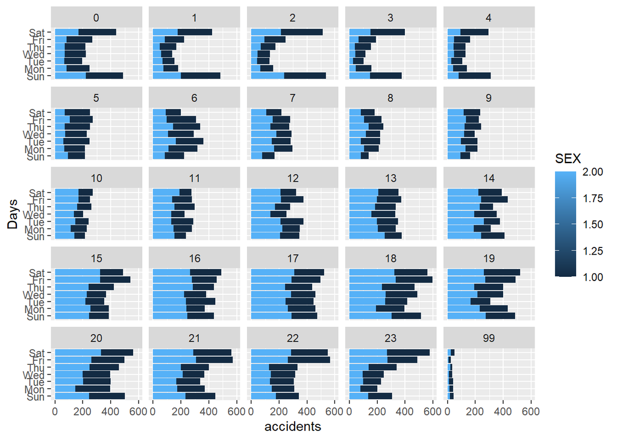

```r
six$DAY_WEEK <- wday(six$DAY_WEEK, label = TRUE)
ggplot(six , aes(DAY_WEEK, n, fill = SEX)) +geom_bar(position="dodge",stat="identity") + labs(y = "accidents", x = "Days") +facet_wrap(~HOUR) +coord_flip()
```

##7. Plot of county Deaths

```r
states <- read_excel('../ds202_lab5/easyName.xlsx')
states <- states %>% rename(Name = 'State Name', STATE = 'State Code', CoName = 'County Name', CoCode = 'County Code')
states <- states %>% distinct( Name, STATE,CoName,CoCode) %>% mutate(STATE = as.integer(STATE), CoCode= as.integer(CoCode))

 county <- five %>%
  select(STATE, INJ_SEV, COUNTY, LATITUDE, LONGITUD)%>% filter(INJ_SEV == 4) %>%
  left_join(states) %>% group_by(STATE, COUNTY, LATITUDE, LONGITUD)
```

[figure not shown]

```r
ggplot(statesOut, aes(x=long, y=lat)) + geom_polygon(aes(group=group)) + geom_polygon(data = county,
               aes(x = LONGITUD, y = LATITUDE))
```

couldnt get the map to work, but each row is a death in the data frame. I was meaning to grab each rows lat and lon and plot it on the map and the more in each state and group the more it got red/ whatever color i chose